# Project 1: coursera Reproducable research

### Reading in the data of a fitness tracker

```r
dat <-  read.csv("C:\\Users\\Lucas\\Downloads\\repdata_data_activity\\activity.csv",na.strings = c("NA","NaN","","#DIV/0!"))
str(dat)
```

```
## 'data.frame':    17568 obs. of  3 variables:
##  $ steps   : int  NA NA NA NA NA NA NA NA NA NA ...
##  $ date    : Factor w/ 61 levels "2012-10-01","2012-10-02",..: 1 1 1 1 1 1 1 1 1 1 ...
##  $ interval: int  0 5 10 15 20 25 30 35 40 45 ...
```

```r
dat$date <- as.Date(dat$date, format = "%Y-%m-%d")
head(dat)
```

```
##   steps       date interval
## 1    NA 2012-10-01        0
## 2    NA 2012-10-01        5
## 3    NA 2012-10-01       10
## 4    NA 2012-10-01       15
## 5    NA 2012-10-01       20
## 6    NA 2012-10-01       25
```

Including packages that are used in the project

```r
library(ggplot2)
library(dplyr)
library(mice)
```

### 1. What is the total number of steps taken per day?

Using dplyr, total number of steps is calculated per day using group_by function Since there are missing values in the dataset, we need to specify na.rm=TRUE

```r
sumdat <- dat %>%
            group_by(date) %>%
            summarize(sumStep=sum(steps),na.rm=TRUE)
total_step <- aggregate(steps ~ date, data = dat, sum, na.rm = TRUE)
str(total_step)
```

```
## 'data.frame':    53 obs. of  2 variables:
##  $ date : Date, format: "2012-10-02" "2012-10-03" ...
##  $ steps: int  126 11352 12116 13294 15420 11015 12811 9900 10304 17382 ...
```

Chunk of the code used to create a plot

```r
newtheme <- theme_bw() +
          theme(plot.title = element_text(color = "Black"))

barfill <- "#4271AE"
barlines <- "#1F3552"
```

### 2. Histogram of the total number of steps taken each day?

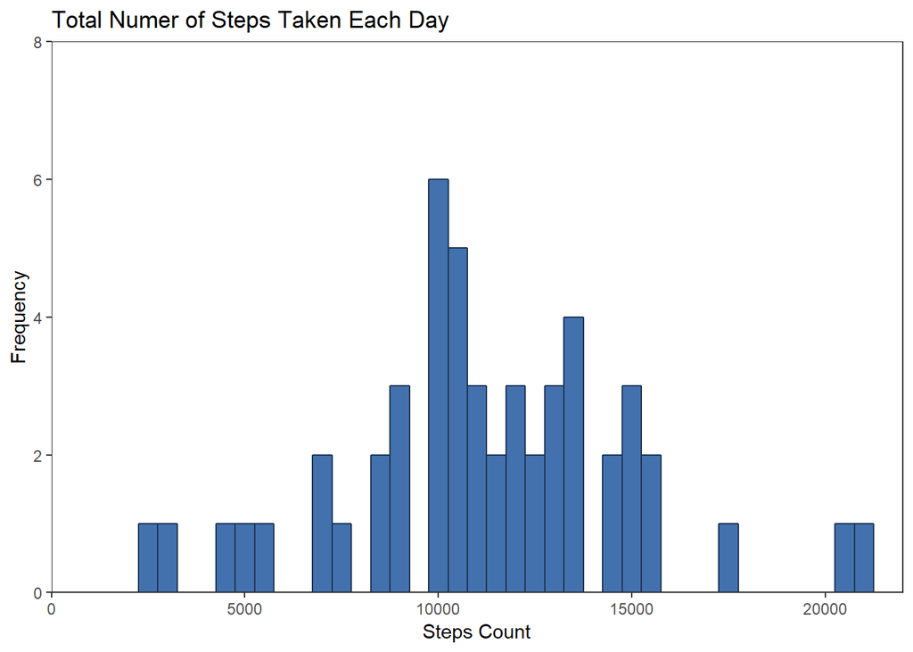

```r
ggplot(sumdat, aes(x=sumStep)) +
  ggtitle("Total Numer of Steps Taken Each Day") +
  geom_histogram(aes(y = ..count..), binwidth = 500,
                 colour = barlines, fill = barfill)+
  scale_y_continuous(name="Frequency",limits=c(0,8),expand = c(0,0))+
  scale_x_continuous("Steps Count",limits=c(0,22000),expand=c(0,0))+
  theme_bw()+
  theme(panel.grid = element_blank())
```

### 3. Mean and median number of steps taken each day

```r
mean(sumdat$sumStep,na.rm=TRUE)
```

```
## [1] 10766.19
```

```r
median(sumdat$sumStep,na.rm=TRUE)
```

```
## [1] 10765
```

Preparing data to create average number of steps per interval

```r
avgdat <- dat %>%
  group_by(interval) %>%
  summarize(avgStep=mean(steps,na.rm=TRUE))
```